# Andmeanalüüsi näide

Tihti, isegi pärast sobiliku andmestikku leidmist, on väga raske mingit kasut sellest saada. Andmehulgad on suured, nõuavad eeltöötlemist, ja inimeste jaoks ei ole eriti hästi loetavad. Selle tõttu, on tihti andmeanalüüs infootsingu üks tähtsamatest komponentidest, mis võimaldab aru saada mis täpselt oli leidud.

Selles *jupyter notebook*'is leiate ettevalmistuva analüüsi näide, mis oli teostatud suhteliselt suure andmestiku peal. Andmestikuna valisin liblikate märkimised mis oli kogutud UK keskkonna muutuse võrgustiku poolt (UK environmental change network). Neid on hästi sobivad näide jaoks kuna on piisavalt hästi organiseeritud, sisaldavad geograafilist ja ajalist komponenti, ja lisaks on kergelt arusaadavad.

# Data analysis example

Often, even after finding a suitable dataset, it is very difficult to gain any insight from it. The datasets are large, require pre-processing, and are not very human-readable. This often makes data analysis one of the most important components of information search, allowing us to makes some sense out of the discovered data.

In this *jupyter notebook* you can find an example of exploratory data analysis performed in a relatively large dataset. The dataset has been collected by the UK Environmental Change Network (UK Environmental Change Network). The data is well-suited for a demonstration since it is relatively well-organized, contains the geographic and temporal components, and additionally, is easily understandable.

# Notebook'i kasutamine

Kui pole kunagi sellise programmeerimis keelega nagu python kokku puutunud võid ainult lugeda seletavat teksti (kuvatatud valges foonis) ja ignoreerida kood (hellidas kastikedes).

Kui aga oled python'iga tutvunud, võid proovida ka aru saada mis koodis toimub. Ma proovisin võimalikult rohkem kommentaare.

Suure tahtmise puhul võid seda notebookit alla tõmmata ja proovida analüüsi muuta või reprodutseerida. Siis tuleb installeerida [Anacondat](https://www.continuum.io/downloads) ja seejärel ka kõik vajalikud püütoni paketid. Neid on võimalik installeerida kahe käsuga käsurealt:

```
conda install numpy pandas matplotlib pillow scipy
pip install folium
```

Kuna UK Environmental Change Network ei luba andmete jagamist kolmandatele isikutele, tuleb ka nende andmeid tõmmata siit: https://doi.org/10.5285/dad68dc4-9e36-457e-aa3a-e7eb816fb508. Saidil leiad ka *Supporting documentation* mis sisaldab andmekirjeldamist. Kui kõik on tehtud, tuleb panna liblikate andmed (ECN_IB1.csv) ja see notebook (butterfly_analysis.ipynb) kättesaadava kataloogi, käivitada *jupyter notebook* anakondast ja suunda teda samasse kataloogi kus andmed asuvad. Avades anakonda aknast näed notebooki jälle oma brauseri aknas, aga nüüd on võimalik kood käivitada (*shift + enter*) ja modifitseeruda.

# Using this notebook

If you have never used a programming language like Python, it is enough if you simply read the explanatory text (displayed on white background) and ignore the code (found in grey boxes).

However, if you are familiar with python, you can also try to figure out what the code does. I tried to add some comments.

If you really wish to modify or change the notebook you will need to install [Anaconda](https://www.continuum.io/downloads) as well as necessary python packages. The later can be done via two commands executed in command line

```
conda install numpy pandas matplotlib pillow scipy
pip install folium
```

As the UK Environmental Change Network does not permit the sharing of data with third parties, you must also pull the data from here: https://doi.org/10.5285/dad68dc4-9e36-457e-aa3a-e7eb816fb508. On that webpage you will also find *Supporting documentation* containing the data description. Finally, put butterfly data (ECN_IB1.csv) and the notebook (butterfly_analysis.ipynb) to a reachable directory, run *jupyter notebook* from Anaconda and direct it to the directory where you put the data. Anaconda should open a window in your browser window in which you will see this notebook again, except now it should be possible to run the code (*shift enter* +) and modify it.

# Eeltöötlus

# Pre-processing

## Lae moodulid

## Import libraries

```python
# make sure that figures are displayed bellow celles
%matplotlib inline
import pandas as pd # it is useful to abbreviate most commonly used packages
import numpy as np
import matplotlib.pyplot as plt
import re
import folium
import json
from PIL import Image
import requests
from urllib.request import urlopen
from scipy import stats
```

## Lae andmed liblikate kohta

## Load butterflies dataset

Siin me loeme liblikate andmed ja eeltöödeldame neid. Koodiblokki all on näidatud esimesed viis ridu 75024-st. Tulbade nimed tähistavad järgmist:

- sitecode : asukoha id kus seire toimus
- sdate : seire kuupäev
- section : konkreetne asukoha osa
- fieldname : liblika id
- value : liblikate arv

Täpsemad definitsioonid saab leida [dokumentatsioonis](http://eidc.ceh.ac.uk/metadata/dad68dc4-9e36-457e-aa3a-e7eb816fb508/zip_export/).

Here we load the butterfly data and do a bit of pre-processing. Bellow the code block, the first five data rows out of 75024 are displayed. Columns contain the following information:

- sitecode : monitoring location
- sdate : monitoring date
- section : specific part of the location
- fieldname : butterfly id
- value : number of observed butterflies

Additional information can be found [here](http://eidc.ceh.ac.uk/metadata/dad68dc4-9e36-457e-aa3a-e7eb816fb508/zip_export/).

```python
df = pd.read_csv('./ECN_IB1.csv')
df.columns = [s.lower() for s in  df.columns] # make all columns lowercase

# Get rid of location ID (LCODE)
df.drop('lcode', axis=1, inplace=True)
# Convert fieldname to categorical variable and date to date
df.fieldname = df.fieldname.astype('category')
# information on different date formats can be found here: http://strftime.org/
df.sdate = pd.to_datetime(df.sdate, format="%d-%b-%y")

df['year'] = pd.DatetimeIndex(df.sdate).year
df['month'] = pd.DatetimeIndex(df.sdate).month
df['dayofweek'] = pd.DatetimeIndex(df.sdate).dayofweek

print('Total number of rows: {}'.format(len(df)))

df.head()
```

```
Total number of rows: 75024
```

|  | sitecode | sdate | section | fieldname | value | year | month | dayofweek |
| --- | --- | --- | --- | --- | --- | --- | --- | --- |
| 0 | T01 | 1993-04-10 | 1 | XX | 0 | 1993 | 4 | 5 |
| 1 | T01 | 1993-04-10 | 2 | XX | 0 | 1993 | 4 | 5 |
| 2 | T01 | 1993-04-10 | 3 | XX | 0 | 1993 | 4 | 5 |
| 3 | T01 | 1993-04-10 | 4 | 84 | 2 | 1993 | 4 | 5 |
| 4 | T01 | 1993-04-10 | 5 | 84 | 1 | 1993 | 4 | 5 |

## Näita liblikate seire asukohad

## Visualize locations of the monitoring sites

Geoandmed on võetud dokumentatsioonist ja on märgistatud kaardi peal. Asukoha nime saamiseks kliki markeri peale.

The geographical data is taken from the supporting documentation and is displayed on map. The markers are clickable.

```python
geo_data = """T01	Drayton	52° 11' 37.95" N 1° 45' 51.95" W	14-Apr-1993 – 19-Dec-2012
T02	Glensaugh	56° 54' 33.36" N 2° 33' 12.14" W	14-Oct-1993 – 26-Dec-2012
T03	Hillsborough	54° 27' 12.24" N 6°  4' 41.26" W	02-Feb-1994 – 27-Dec-2012
T04	Moor House - Upper Teesdale	54° 41' 42.15" N 2° 23' 16.26" W	06-Oct-1992 – 24-Dec-2012
T05	North Wyke	50° 46' 54.96" N 3° 55' 4.10" W	29-Sep-1993 – 26-Dec-2012
T06	Rothamsted	51° 48' 12.33" N 0° 22' 21.66" W	02-Feb-1994 – 12-Dec-2012
T07	Sourhope	55° 29' 23.47" N 2° 12' 43.32" W	08-Dec-1993 – 26-Dec-2012
T08	Wytham	51° 46' 52.86" N 1° 20' 9.81" W	09-Jun-1993 – 12-Dec-2012
T09	Alice Holt	51°  9' 16.46" N 0° 51' 47.58" W	27-Apr-1994 – 12-Dec-2012
T10	Porton Down	51°  7' 37.83" N 1° 38' 23.46" W	17-Jan-1996 – 26-Jan-2000
T11	Y Wyddfa - Snowdon	53°  4' 28.38" N 4°  2' 0.64" W	02-Jul-1997 – 27-Dec-2012
T12	Cairngorms	57°  6' 58.84" N 3° 49' 46.98" W	06-Oct-1999 – 26-Dec-2012"""

# regexp string to parse coordinates
match_str = r"""(\d+)°\s+(\d+)'\s+(\d+\.\d+)"\s+N\s+(\d+)°\s+(\d+)'\s+(\d+\.\d+)"\s+W\s*"""
geo_data = geo_data.splitlines()
geo_data = [l.split('\t') for l in geo_data] # split by tab
coords = []
for line in geo_data:
    name = '{} {}'.format(line[0], line[1])
    coord = re.findall(match_str, line[2])
    coord = list(map(float, coord[0]))
    # convert to decimal degrees
    north = coord[0] + coord[1]/60.0 + coord[2]/3600.0
    west = coord[3] + coord[4]/60.0 + coord[5]/3600.0
    coords.append([north, -west, name])

# create map using folium
map_gb = folium.Map(location=[54.3781, -3.4360], zoom_start=6,
                       tiles='Stamen Terrain')
# and place markers on it
for north, east, name in coords:
    folium.Marker([north, east], popup=name).add_to(map_gb)

# convert coords to numpy array for future use
coords = np.array(coords)
# dispaly map
map_gb
```

[interactive chart not shown]

# Uuri andmeid

# Explore data

## Kus ja kui tihti olid mõõtmised tehtud

## Measurement frequencies and locations

Neli järgmist bar charti näitavad kui tihti mõõtmised olid tehtu sõltuvalt aastast, kuust, päevast ja asukohast. Nendest allpool asuv ajajoon näitab mõõtmisi erinevatel asukohadel läbi aastaid.

Four following bar chars demonstrate how often measurements were made depending on the year, month, weekday, and location. Bellow them is timeline demonstrating measurements at different locations throughout the years.

[output not shown]

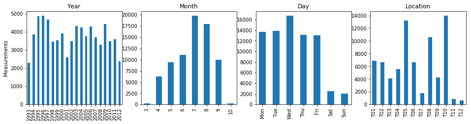

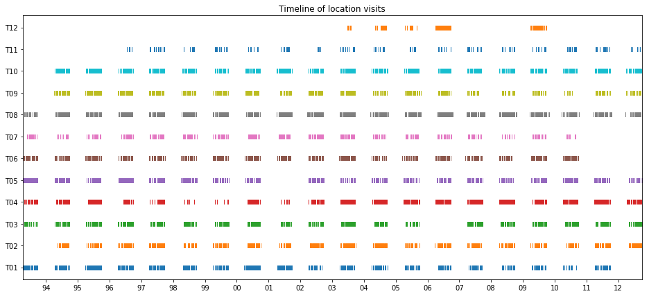

```python
# check when the measurements took place
print('Measurements took place on',len(df.sdate.unique()),'different days')
print('The first measurement occured on',min(df.sdate).strftime('%d-%b-%Y'))
print('The last measurement occured on',max(df.sdate).strftime('%d-%b-%Y'))

fig, (ax1,ax2,ax3,ax4) = plt.subplots(ncols=4, figsize=(16, 3.5))

ax1.set_title('Year')
ax1.set_ylabel('Measurements')
df['year'].value_counts(sort=False).plot(kind="bar", ax=ax1)
ax2.set_title('Month')
df['month'].value_counts(sort=False).plot(kind="bar", ax=ax2)
ax3.set_title('Day')
df['dayofweek'].value_counts(sort=False).plot(kind="bar", ax=ax3)
ax3.set_xticklabels(['Mon','Tue','Wed','Thu','Fri','Sat','Sun'])
ax4.set_title('Location')
loc_measurements = df['sitecode'].value_counts().sort_index()
loc_measurements.plot(kind="bar", ax=ax4)
plt.show()

# timeframe
import matplotlib.dates as mdates
years = mdates.YearLocator()   # every year
yearsFmt = mdates.DateFormatter('%y')

fig, ax = plt.subplots(figsize=(16,7))
locations = df.sitecode.unique()
for i, loc in enumerate(locations):
    location_visits = df[df.sitecode==loc]
    ax.plot(location_visits.sdate, [i,]*len(location_visits), '|')
ax.set_yticks(list(range(len(locations))))
ax.set_yticklabels(locations)
ax.set_title('Timeline of location visits')
ax.xaxis.set_major_locator(years)
ax.xaxis.set_major_formatter(yearsFmt)
_ = ax.set_xlim(df.sdate.min(), df.sdate.max())
```

## Liblikate koguarv sõltuvalt liigist

## Number of observed butterflies by species

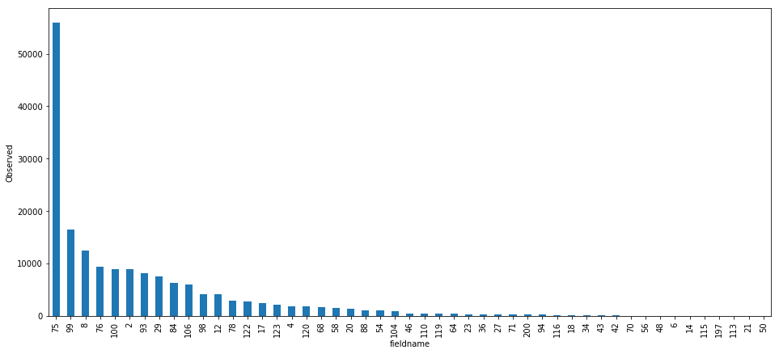

```python
fig, ax = plt.subplots(figsize=(16, 7))

cumult_butterflies = pd.pivot_table(df, values='value', index=['fieldname'], aggfunc=sum)
cumult_butterflies.drop('XX', inplace=True)
cumult_butterflies.sort_values(ascending=False, inplace=True)
cumult_butterflies.plot(kind='bar', ax=ax)
ax.set_ylabel('Observed')

top12_butterflies = list(cumult_butterflies.items())[:12]
```

## Liblikate pildid

## Pictures of butterflies

Kuna liblikate koodid ei anna palju informatsiooni, võtame wikipeediast nende pildid kasutas wikipeedia poolt pakutavata api'd. Tabelit, mis seob liblikate koodid nende nimetega on võimalik leida lisadokumentatsioonis.

Since butterflies’ codes do not tell us much, we can use Wikipedia API to get their images. The table which relates butterflies id to their names can be found in supporting documentation.

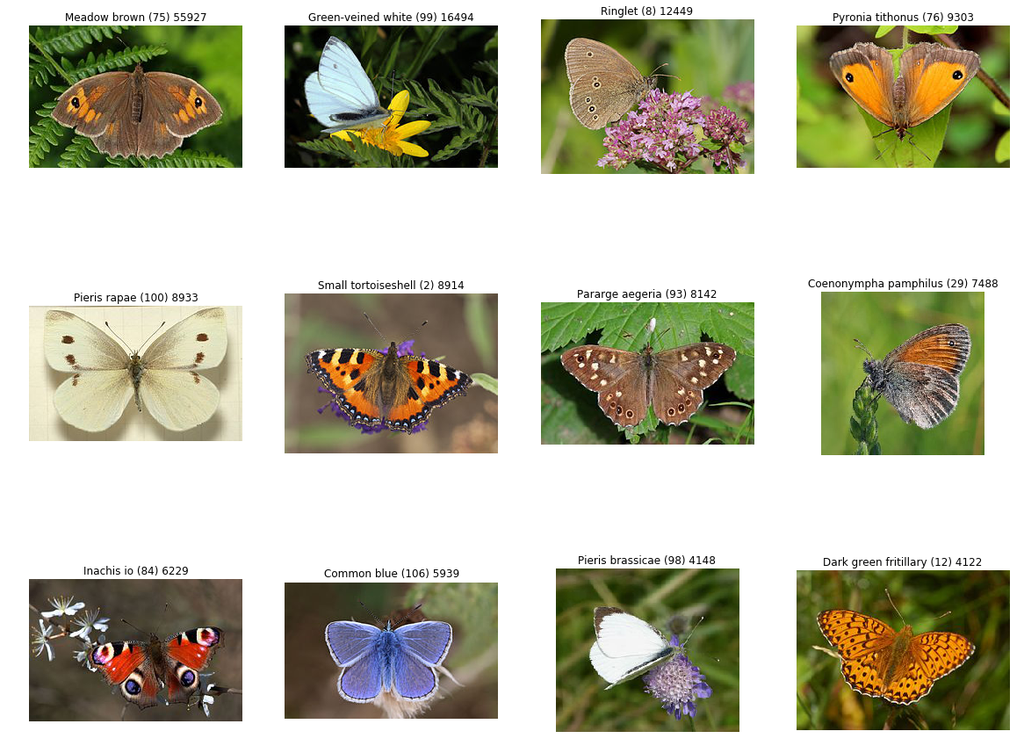

```python
butterfly_names = {'10': 'Black-veined white', '100': 'Pieris rapae', '102': 'Silver-studded blue', '104': 'Polygonia c-album', '106': 'Common blue',
 '108': 'Bath white', '110': 'Grizzled skipper', '112': 'Black hairstreak', '113': 'White-letter hairstreak',
 '115': 'Brown hairstreak', '116': 'Purple hairstreak', '118': 'Lulworth skipper', '119': 'Essex skipper',
 '12': 'Dark green fritillary', '120': 'Small skipper', '122': 'Red admiral', '123': 'Painted lady',
 '13': 'High brown fritillary', '14': 'Pearl-bordered fritillary', '15': 'Queen of Spain fritillary',
 '17': 'Silver-washed fritillary', '18': 'Small pearl-bordered fritillary', '197': 'Mixed whites', '2': 'Small tortoiseshell',
 '20': 'Brown argus', '200': 'Small/Essex skipper', '21': 'Northern brown argus', '23': 'Green hairstreak',
 '25': 'Chequered skipper', '27': 'Holly blue', '29': 'Coenonympha pamphilus', '30': 'Large heath', '32': "Berger's clouded yellow",
 '33': 'Pale clouded yellow', '34': 'Clouded yellow', '36': 'Small blue', '38': 'Mazarine blue', '4': 'Orange tip',
 '40': 'Monarch', '42': 'Scotch argus', '43': 'Mountain ringlet', '46': 'Dingy skipper', '48': 'Grayling',
 '50': 'Marsh fritillary', '52': 'Short-tailed blue', '54': 'Brimstone', '56': 'Duke of Burgundy', '58': 'Silver-spotted skipper',
 '6': 'Purple emperor', '60': 'Long-tailed blue', '62': 'Wood white', '64': 'White admiral', '66': 'Large copper',
 '68': 'Small copper', '70': 'Adonis blue', '71': 'Chalkhill blue', '73': 'Large blue', '75': 'Meadow brown',
 '76': 'Pyronia tithonus', '78': 'Marbled white', '8': 'Ringlet', '80': 'Heath fritillary', '81': 'Glanville fritillary',
 '83': 'Camberwell beauty', '84': 'Inachis io', '85': 'Large tortoiseshell', '88': 'Large skipper', '90': 'Swallowtail',
 '93': 'Pararge aegeria', '94': 'Wall brown', '98': 'Pieris brassicae', '99': 'Green-veined white'}

def get_wiki_pageimage(page_title):
    wiki_api_string = "https://en.wikipedia.org/w/api.php?action=query&titles={query}\
&prop=pageimages&format=json&pithumbsize=250&redirects"
    api_url = wiki_api_string.format(query=page_title)
    response = requests.get(api_url).text
    json_response = json.loads(response)
    # since we don't know page id, we have to use somewhat hackish approach
    page_id_dic = list(json_response["query"]["pages"].values())[0]
    try:
        img_url = page_id_dic["thumbnail"]['source']
    except KeyError:
        #fallback on another method
        import wikipedia
        print("Warning, thumbnail for {} was not found. Can lead to unexpected resultsd.".format(page_title))
        img_url = wikipedia.page(title="University of Tartu").images[0]
    img_data = urlopen(img_url)
    return Image.open(img_data)

fig = plt.figure(figsize=(20,15))
cols = 4
rows = 3

# Focus on 12 most common butterflies
top12_data = []
for i, (code, freq) in enumerate(top12_butterflies):
    name = butterfly_names[code]
    ax = fig.add_subplot(rows, cols, i + 1)
    ax.set_title('{} ({}) {}'.format(name, code, freq))
    # Get buttefly thumbnail from the wiki article with the butterfly name
    img = get_wiki_pageimage(name)
    ax.imshow(img)
    ax.axis('off')
    top12_data.append([name, code, img])

plt.subplots_adjust(hspace=0.7, wspace=0.2)
```

## Kokkuvõtte külastustest

## Summarizing site visits

Kõik liblikate vaatamisasukohad on jagatud erinevateks sektoriteks kus liblikaid loendatakse. Võime eeldada et neid sektorid on väga sarnased ja esitleme iga mõõtmist kasutades ainult kuupäeva ja asukohta. Sellisel andmete esitlusel muutavad järgnevad analüüsid lihtsamaks.

All butterfly measurement locations are divided into different sectors on which butterflies are counted. We can assume that these sectors are similar and describe each measurement using only the date and location. This will make subsequent analysis easier.

```python
field_summary = []

# initialize dates and codes with their initial values
sitecode = 'T01'
sdate = pd.Timestamp('1993-04-10 00:00:00')
encountered_buterflies = {}
for i, row in df.iterrows():
    # if a new field is encountered
    if (row['sdate'] != sdate or row['sitecode'] != sitecode):
        # save previous field visit data
        datum = [sdate, sitecode]
        if not encountered_buterflies: # no butterflies encountered
            datum.extend([0, 0, {}])
        else: # record summary
            datum.append(len(encountered_buterflies.keys()))
            datum.append(sum(encountered_buterflies.values()))
            datum.append(encountered_buterflies)
        field_summary.append(datum)
        # update variables
        encountered_buterflies = {}
        sdate = row['sdate']
        sitecode = row['sitecode']
    # if we have encountered butterfly on a field...
    if row['fieldname'] != 'XX':
        encountered_buterflies[row['fieldname']] = encountered_buterflies.get(row['fieldname'], 0) + row['value']
# do not forget to save the very last field visit...
datum = [sdate, sitecode]
if not encountered_buterflies: # no butterflies encountered
    datum.extend([0, 0, {}])
else: # record summary
    datum.append(len(encountered_buterflies.keys()))
    datum.append(sum(encountered_buterflies.values()))
    datum.append(encountered_buterflies)
field_summary.append(datum)

# convert it to data frame
field_summary = pd.DataFrame(field_summary,
     columns=['date', 'location', 'variety', 'total', 'encounters'])
# add weekofyear counter for later use
field_summary['weekofyear'] = pd.DatetimeIndex(field_summary.date).weekofyear
field_summary.head()
```

|  | date | location | variety | total | encounters | weekofyear |
| --- | --- | --- | --- | --- | --- | --- |
| 0 | 1993-04-10 | T01 | 2 | 5 | {'84': 3, '2': 2} | 14 |
| 1 | 1993-04-21 | T01 | 1 | 7 | {'2': 7} | 16 |
| 2 | 1993-04-30 | T01 | 6 | 34 | {'2': 12, '84': 14, '98': 1, '100': 1, '4': 3,... | 17 |
| 3 | 1993-05-06 | T01 | 3 | 15 | {'2': 10, '84': 4, '100': 1} | 18 |
| 4 | 1993-05-14 | T01 | 0 | 0 | {} | 19 |

## Rekordid ja jaotused

## Records and distributions

Allpool on toodud graafikud mis näitavad juhtumite arv millel teadlastele õnnestus leida N erinevate liblikalike (vasakul) ja N liblikaid kokku (paremal).

On the figure bellow you can see the number of cases when scientists managed to observe N different butterfly species (left) and N total butterflies (right).

```
Most butterflies observed in a single trip: 802. This took place in T10 on 1998-Aug-13.
Most butterflies species observed in a single trip: 22. This took place in T09 on 1996-Aug-14.
```

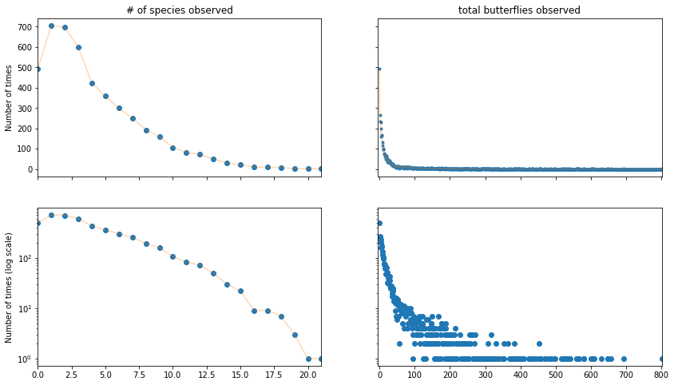

```python
# compute recods
most_butterflies_row = field_summary.loc[np.argmax(field_summary.total)]
print('Most butterflies observed in a single trip: {}. \
This took place in {} on {}.'.format(most_butterflies_row.total, most_butterflies_row.location,
                                     most_butterflies_row.date.strftime('%Y-%b-%d')))
most_butterflies_species = field_summary.loc[np.argmax(field_summary.variety)]
print('Most butterflies species observed in a single trip: {}. \
This took place in {} on {}.'.format(most_butterflies_species.variety, most_butterflies_species.location,
                                     most_butterflies_species.date.strftime('%Y-%b-%d')))

# plot variety and totals distributions
fig, ((ax1, ax2), (ax3,ax4)) = plt.subplots(nrows=2, ncols=2, sharex='col', figsize=(14,8), sharey='row')

ax1.set_title('# of species observed')
ax1.set_ylabel('Number of times')
y, edges = np.histogram(field_summary['variety'], bins=field_summary['variety'].max())
ax1.plot(edges[:-1], y, 'o')
ax1.plot(edges[:-1], y, '-', alpha=.3)
ax3.set_ylabel('Number of times (log scale)')
ax3.semilogy(edges[:-1], y, 'o')
ax3.semilogy(edges[:-1], y, '-', alpha=.3)
ax3.set_xlim(edges[0], edges[-2])

ax2.set_title('total butterflies observed')
y, edges = np.histogram(field_summary['total'], bins=field_summary['total'].max())
ax2.plot(edges[:-1], y, '.')
ax2.plot(edges[:-1], y, '-', alpha=.3)
ax4.semilogy(edges[:-1], y, 'o')
_ = ax4.set_xlim(-4, edges[-2])
```

## Pikaajalised trendid

## Long term trends

Graafikud näitavad kuidas keskmine liblikate ja liblikate liikide arv sõltub ajast.

The figures show dependence of average number of butterflies and their species variety on time.

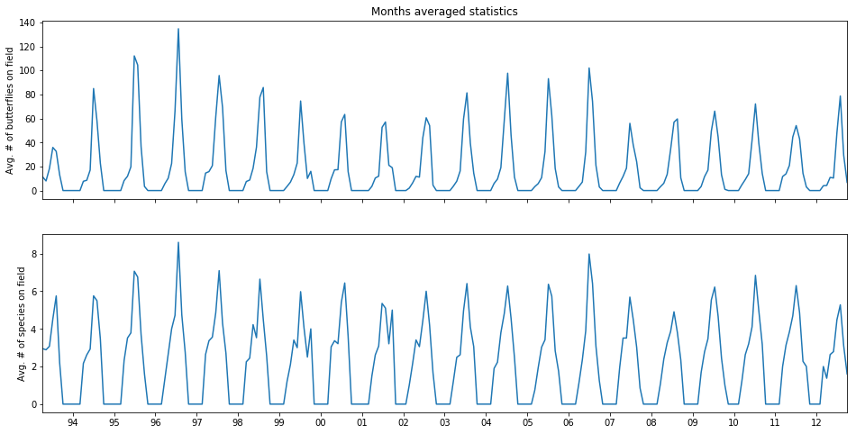

```python
# create array with passed months
start_date = pd.Timestamp('1993-04-10')
time_dif = field_summary.date - start_date # time in ns since the start_date
months_since_begining = (time_dif.get_values().astype(np.float)/1.0e9/3600/24/30).astype(np.int)
# group measurments by passed months and find averages
field_summary['passed_month'] = months_since_begining
passedmonths_agg_data = field_summary[['passed_month', 'total', 'variety']].groupby('passed_month').agg(np.mean)
# fill in winter months which are missing
for i in range(passedmonths_agg_data.index.max()):
    if not (i in passedmonths_agg_data.index):
        passedmonths_agg_data.loc[i, :] = [0, 0]
passedmonths_agg_data.sort_index(inplace=True)
# go back from months to dates so that plots have nice x-axis
passed_months_time_data = [start_date + pd.Timedelta(30, unit='D')*i for i in passedmonths_agg_data.index]
passed_months_time_data = pd.Series(passed_months_time_data)


# Plot time data
fig, (ax1, ax2) = plt.subplots(nrows=2, sharex=True, figsize=(16,8))
ax1.set_title('Months averaged statistics')
ax1.plot(passed_months_time_data, passedmonths_agg_data.total, '-')
ax1.set_ylabel('Avg. # of butterflies on field')
ax2.plot(passed_months_time_data, passedmonths_agg_data.variety, '-')
ax2.set_ylabel('Avg. # of species on field')
#plt.plot(weekofyear_data.index, weekofyear_data.total)
years = mdates.YearLocator()   # every year
yearsFmt = mdates.DateFormatter('%y')
ax1.xaxis.set_major_locator(years)
ax1.xaxis.set_major_formatter(yearsFmt)
_ = ax1.set_xlim(passed_months_time_data.min(), passed_months_time_data.max())
```

## Aasta trendid

## Annual trends

Eelmistel kahel graafikutel on näha et liblikate populatsioon eriti palju aastast ei sõltu. Sõltub ta aga aastaperioodilt. All toodud graafikud näitavad liblikate arved sõltuvalt aasta nädalast.

Previous two figures suggest that the butterfly population doesn't experience significant long term variation. However, it clearly does depend on the period of the year. Two figures below demonstrate the dependency between number of butterflies and the week of a year.

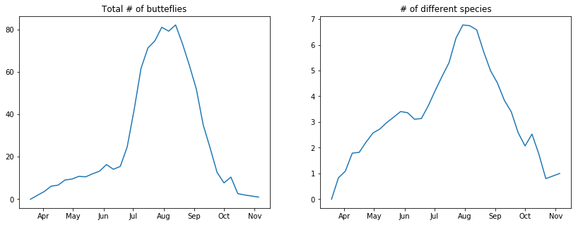

```python
# generate week of the year based statistics
weekofyear_data = field_summary[['weekofyear', 'total', 'variety']].groupby('weekofyear').agg(np.mean)
# create nice x-axis for matplotlib
ref_date = pd.Timestamp('2017-01-01')

# plot
fig, (ax1, ax2) = plt.subplots(ncols=2, figsize=(14, 5))
week_axis = [ref_date + pd.Timedelta(7, unit='D')*i for i in weekofyear_data.index]
week_axis = pd.Series(week_axis)
weekFmt = mdates.DateFormatter('%b')
ax1.xaxis.set_major_formatter(weekFmt)
ax2.xaxis.set_major_formatter(weekFmt)
ax1.set_title('Total # of butteflies')
ax2.set_title('# of different species')
ax1.plot(week_axis, weekofyear_data.total)
ax2.plot(week_axis, weekofyear_data.variety)
```

## Liblikaliigi aktiivsus aasta jooksul

## Activity of different species throught the year

Järgmiselt, võime vaadata mitte summaarse liblikate populatsioonile, vaid konkreetsete liigi peal. Ruumi hoidmise jaoks võtame ainult 12 kõige levinumaid tüüpe.

Instead of inspecting the trends of the whole butterfly population, let's take a look at particular species. Due to the space constraints we focus only on 12 most frequently encountered species.

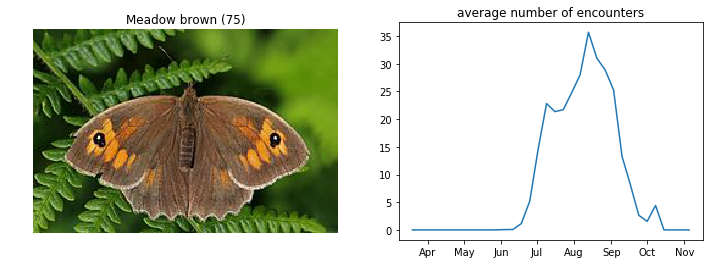

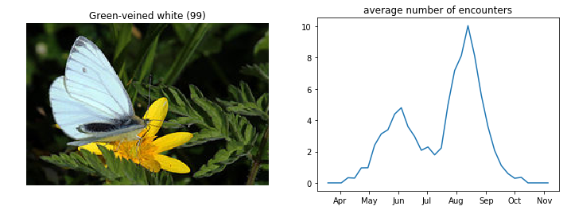

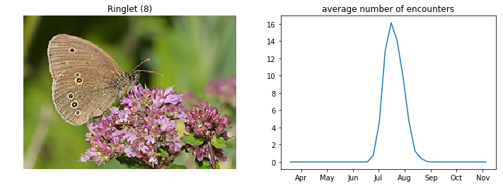

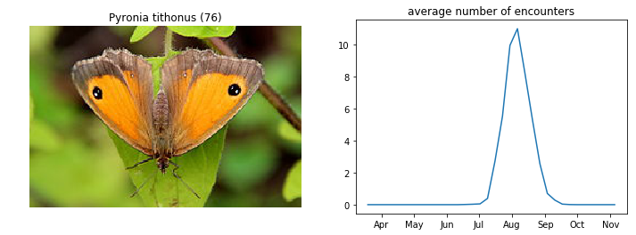

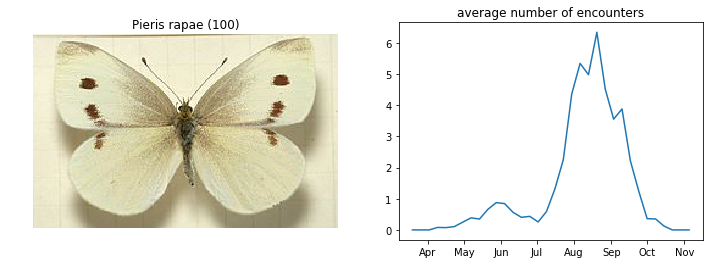

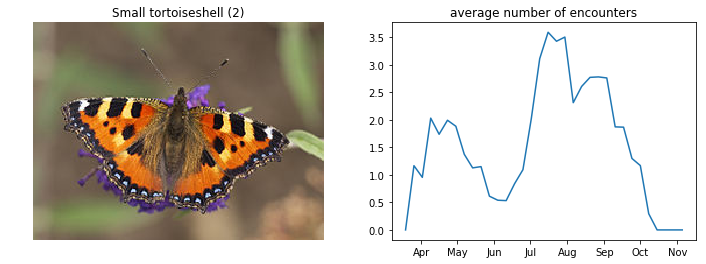

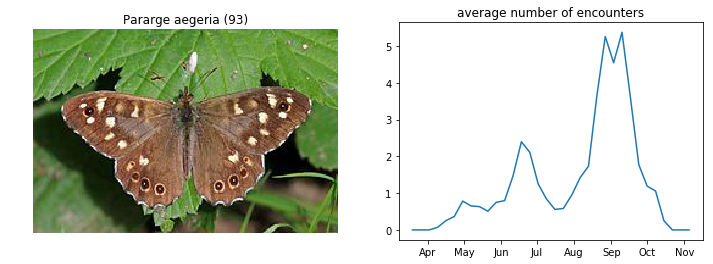

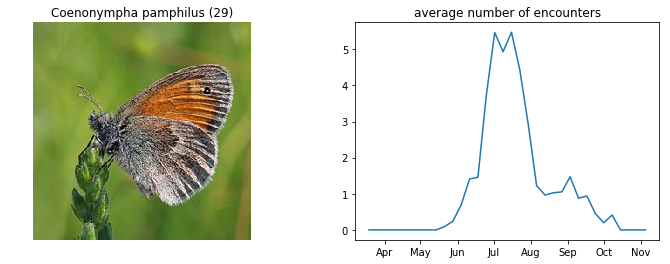

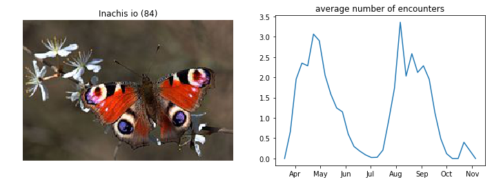

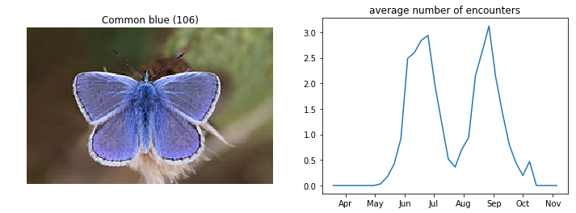

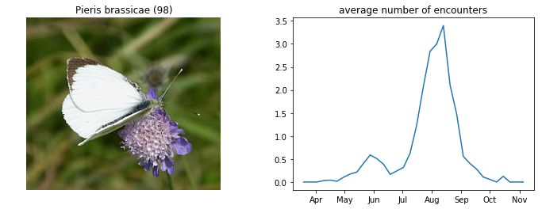

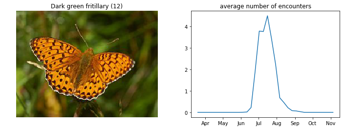

```python
# generate week of the year based statistics, but don't aggregate
field_summary['weekofyear'] = pd.DatetimeIndex(field_summary.date).weekofyear
weekofyear_data = field_summary[['weekofyear', 'encounters']].groupby('weekofyear')

for name, code, img in top12_data:
    fig, (ax1, ax2) = plt.subplots(ncols=2, figsize=(12, 4))
    ax1.imshow(img)
    ax1.axis('off')
    ax1.set_title('{} ({})'.format(name, code))
    byweek_data = []
    for week in weekofyear_data.groups.keys():
        number_of_observations_for_week = []
        week_group = weekofyear_data.get_group(week)
        for encounter in week_group.encounters:
            number_of_observations_for_week.append(encounter.get(code, 0))
        byweek_data.append([week, np.mean(number_of_observations_for_week)])
    byweek_data = np.asarray(byweek_data)
    ax2.plot(week_axis, byweek_data[:,1])
    ax2.set_title('average number of encounters')
    ax2.xaxis.set_major_formatter(weekFmt)
    plt.show()
```

# Klasteranalüüs

# Cluster analysis

## Asukohtade klasterdamine lähtudes nende geograafilistest koordinaatidest

## Location clustering base on their coordinates

Kõigepealt, selleks et kontrollida et püütoni (scipy) algoritm töötab, proovime klasterdada liblikate seire asukohad lähtudes ainult nende korinaatidest. Klasterdamise tulemusena ehitame dendrogrami, mis on näidatud allpool.

First of all, in order to check python's (scipy) clustering algorithm, let's cluster butterfly monitoring locations using only their coordinates. The results of clustering are plotted using dendrogram.

```
Cophenetic Correlation Coefficient, c=0.795
(closer to 1 - better clustering, closer to 0 - worse)
```

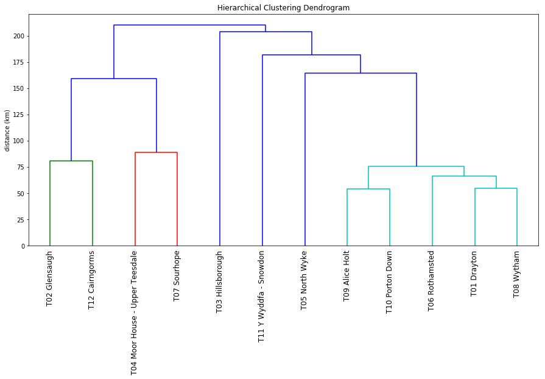

```python
# needed imports
from scipy.cluster.hierarchy import dendrogram, linkage
from scipy.cluster.hierarchy import fcluster, cophenet
from scipy.spatial.distance import pdist


def earth_dist(coord1, coord2):
    """Distance between two coords (in degrees) converted to km
    Formula from: https://en.wikipedia.org/wiki/Haversine_formula"""
    R = 6378.137 # Radius of earth in KM
    (lat1, lon1), (lat2, lon2) = coord1, coord2
    dLat = lat2*np.pi/180 - lat1*np.pi/180 # latitude difference in radians
    dLon = lon2*np.pi/180 - lon1*np.pi/180 # longtitude difference in radians
    # haversine of central angle
    a = np.sin(dLat/2)**2 + np.cos(lat1*np.pi/180)*np.cos(lat2*np.pi/180)*np.sin(dLon/2)**2
    dRad = 2*np.arctan2(np.sqrt(a), np.sqrt(1-a)) # angle between two points in radians
    return R*dRad # distance in km

# cluster cities into groups
Z = linkage(coords[:,:2], 'single', metric=earth_dist)
c, coph_dists = cophenet(Z, pdist(coords[:,:2]))
print('Cophenetic Correlation Coefficient, c={:.3f}'.format(c))
print('(closer to 1 - better clustering, closer to 0 - worse)')

# calculate dendrogram
plt.figure(figsize=(15, 7))
plt.title('Hierarchical Clustering Dendrogram')
plt.ylabel('distance (km)')
dendrogram(
    Z,
    leaf_rotation=90.,  # rotates the x axis labels
    labels=coords[:,2]

)
plt.show()
```

## Visualiseerime klasterdamise tulemused kaardil

## Visualizing clustering resuilts on map

Dendrogrammist on näha et me võime mõistlikult jagada kõik meie asukohad jagada erinevateks rühmadeks. Visualiseerime nüüd neid rühmad kaardi peal, kasutades erinevad värvid erinevate rühmade jaoks.

Dendrogram suggest that it is possible to split all our locations in 6 different groups. The splitting is shown on the map bellow, with different groups coloured in different colours.

```python
# from the map we can estimate
k=6
cluster = fcluster(Z, k, criterion='maxclust')
print('{:^12} {:<25}'.format('Cluster ID', 'Location'))



map_gb2 = folium.Map(location=[54.3781, -3.4360], zoom_start=6,
                       tiles='Stamen Terrain')

colors = ['#2ca02c', '#a02c2c', '#3fcece', '#ff7f0e',   '#ff9896',  '#1f77b4']

for cluster_idx, (north, east, name) in zip(cluster, coords):
    print('{:^12} {:<25}'.format(cluster_idx, name.strip()))
    coord = [float(north), float(east)]
    folium.CircleMarker(location=coord, radius=50,
                    popup='{}, {}'.format(name, cluster_idx), color=colors[cluster_idx-1],
                    fill_color=colors[cluster_idx-1]).add_to(map_gb2)
coords = np.array(coords)
map_gb2
```

```
 Cluster ID  Location
     3       T01 Drayton
     1       T02 Glensaugh
     6       T03 Hillsborough
     2       T04 Moor House - Upper Teesdale
     4       T05 North Wyke
     3       T06 Rothamsted
     2       T07 Sourhope
     3       T08 Wytham
     3       T09 Alice Holt
     3       T10 Porton Down
     5       T11 Y Wyddfa - Snowdon
     1       T12 Cairngorms
```

[interactive chart not shown]

## Asukohade klasterdamine lähtudes nende liblikate populatsioonides

## Location clustering base on their butterfly populations

```
Cophenetic Correlation Coefficient, c=0.797
(closer to 1 - better clustering, closer to 0 - worse)
```

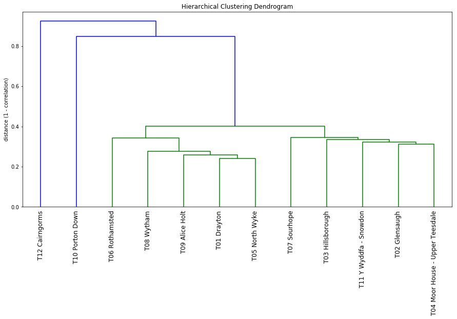

```python
# first of all, get unique butterflies codes
uq_buterflies_codes = sorted(df[df.fieldname != 'XX'].fieldname.unique().astype(str))

empty_dict = {buter_id : 0 for buter_id in uq_buterflies_codes}
# create function for aggregating various buttefly encounters
def merge_encounter_dictionaries(dicts):
    """Takes dictionaries representing field visits (encounters) and returns
    combined encounters dictionary"""
    super_dict = empty_dict.copy()
    for d in dicts:
        if d != 0:
            for k, v in d.items():
                super_dict[k] = super_dict[k] + v
    return super_dict

pivot = pd.pivot_table(field_summary, values='encounters', index=['location', 'weekofyear'],
                       aggfunc=merge_encounter_dictionaries, dropna=False, fill_value=0)

X = []
for location, _ in pivot.groupby(level=0):
    # get a matrix, with rows corresponding to weeks of a year (starting from 11-th)
    # and columns to total number of encounters with all kinds of butterflies
    encounter_dics_and_missing_values = list(pivot[location].values)
    encounter_dics = [d if d != 0 else empty_dict for d in encounter_dics_and_missing_values]
    characteristic_df = pd.DataFrame(encounter_dics)
    # make sure columns have identical ordering
    characteristic_df = characteristic_df[uq_buterflies_codes]
    characteristic_mat = characteristic_df.values
    # normalize each row to get probabilities
    row_sums = characteristic_mat.sum(axis=1)
    row_sums[row_sums==0] = 1 # avoid /0
    characteristic_mat = characteristic_mat/row_sums[:, np.newaxis]
    # flatten it to obtain vector characterizing location
    characteristic_v = characteristic_mat.flatten()
    X.append(characteristic_v)
X = np.asarray(X)
# compute reduced distances between characteristic vectors
y = pdist(X, 'correlation')
# cluster locations into groups
Z = linkage(y, 'single')
c, coph_dists = cophenet(Z, y)
print('Cophenetic Correlation Coefficient, c={:.3f}'.format(c))
print('(closer to 1 - better clustering, closer to 0 - worse)')

# calculate dendrogram
plt.figure(figsize=(15, 7))
plt.title('Hierarchical Clustering Dendrogram')
plt.ylabel('distance (1 - correlation)')
dendrogram(
    Z,
    leaf_rotation=90.,  # rotates the x axis labels
    labels=coords[:,2]
)
plt.show()
```

## Visualiseerime klasterdamise tulemused kaardil

## Visualizing clustering resuilts on map

Vaadates ülevale asuv dendrogramile, jagame kõik asukohad neljaks gruppiks. Tulemused on päris huvitavad. Ilmselt, punane ja roheline rühmad vastavad "põhjalasele" ja "lõunasele" populatsioonidele (Suurbritannia kontekstis). On võimalik pakkuda, et neljas rühm, T12 Cairngorms, on eriline kuna liblikate seire asukoht asub päris kõrge mägedes. Põhjus, miks aga T10 Porton Down ei ole ühtegi rühma sees ei ole lihtne üles leida. Võib olla on see seotud sellega, kuidas andmed olid kogutud seal, või äkki, unikaalsete liblikate liikidega, mis mingi põhjuse pärast elavad seal.

```python
# from the map we can estimate
k=4
cluster = fcluster(Z, k, criterion='maxclust')
print('{:^12} {:<25}'.format('Cluster ID', 'Location'))



map_gb2 = folium.Map(location=[54.3781, -3.4360], zoom_start=6,
                       tiles='Stamen Terrain')

colors = ['#2ca02c', '#a02c2c', '#3fcece', '#ff7f0e',   '#c906e2',  '#1f77b4']

for cluster_idx, (north, east, name) in zip(cluster, coords):
    print('{:^12} {:<25}'.format(cluster_idx, name.strip()))
    coord = [float(north), float(east)]
    folium.CircleMarker(location=coord, radius=50,
                    popup='{}, {}'.format(name, cluster_idx), color=colors[cluster_idx-1],
                    fill_color=colors[cluster_idx-1]).add_to(map_gb2)
coords = np.array(coords)
map_gb2
```

```
 Cluster ID  Location
     1       T01 Drayton
     2       T02 Glensaugh
     2       T03 Hillsborough
     2       T04 Moor House - Upper Teesdale
     1       T05 North Wyke
     1       T06 Rothamsted
     2       T07 Sourhope
     1       T08 Wytham
     1       T09 Alice Holt
     3       T10 Porton Down
     2       T11 Y Wyddfa - Snowdon
     4       T12 Cairngorms
```

[interactive chart not shown]